# IC50 estimations from pilot EnVision data

Evert Bosdriesz

2021-07-19

# Background

Data analyzed in this notebook is from a pilot experiment performed between 11-09 and 15-09-2017.

MCF10A WT and PI3K KI mutant strain where screened against a number of MAPK and AKT-pathway targeting drugs. The main purpose was to Establish IC50-values in a 4-day viability assay.

# Data preparation

- Each biological replicate spanned two plates, (because not all drugs fit on the same plate). Each drug was measured in technical replicates on the same plate.
- Each drug was measured in “biological” triplicate on different plates. Replicates were performed on the same day.
- The MCF10A WT and PI3Kmut cell lines were measured on separate plates

In total, this gives 12 plates

```r
data_path <- here("data" , "EnVision", "2017-09-15")

# Annotation excel sheet
annot <- read_xlsx(
  file.path(data_path, "/Dose Responses MCF10A Parental&PI3K Report.xlsx"),
  sheet = "Tabular detail"
  )
colnames(annot) <- str_replace_all(make.names(colnames(annot)), "\\.+", "_")

# Well annotation file
annot <- annot %>%
  rename(
    Well = Dispensed_well,
    Drug = Fluid_name,
    Concentration = Dispensed_conc_
    ) %>%
  select(Plate, Well, Drug, Concentration)

# There are 6 plates for each cell line, with
# Viability data of the 3 replicates plates are in the same csv file
# MCF10A-WT plates
wt_1_path <- file.path(data_path, "CTB_MCF10A_PAR_DRA_20170915.csv")
wt_1_1 <- read_csv(wt_1_path, skip = 9,  n_max = 16)
wt_1_2 <- read_csv(wt_1_path, skip = 36, n_max = 16)
wt_1_3 <- read_csv(wt_1_path, skip = 63, n_max = 16)
wt_2_path <- file.path(data_path, "CTB_MCF10A_PAR_DRB_20170915.csv")
wt_2_1 <- read_csv(wt_2_path, skip = 9,  n_max = 16)
wt_2_2 <- read_csv(wt_2_path, skip = 36, n_max = 16)
wt_2_3 <- read_csv(wt_2_path, skip = 63, n_max = 16)
# # MCF1A PI3Kmutant plates
pi3k_1_path <- file.path(data_path, "CTB_MCF10A_PI3K_DRA_20170915.csv")
pi3k_1_1 <- read_csv(pi3k_1_path, skip = 9,  n_max = 16)
pi3k_1_2 <- read_csv(pi3k_1_path, skip = 36, n_max = 16)
pi3k_1_3 <- read_csv(pi3k_1_path, skip = 63, n_max = 16)
pi3k_2_path <- file.path(data_path, "CTB_MCF10A_PI3K_DRB_20170915.csv")
pi3k_2_1 <- read_csv(pi3k_2_path, skip = 9,  n_max = 16)
pi3k_2_2 <- read_csv(pi3k_2_path, skip = 36, n_max = 16)
pi3k_2_3 <- read_csv(pi3k_2_path, skip = 63, n_max = 16)
rm(wt_1_path, wt_2_path, pi3k_1_path, pi3k_2_path)
```

Cast the data in a tidy format. The technical replicates are combined by taking their mean.

```r
tidy_plate <- function(df, Plate, Rep, annot){
  df %>%
    gather(Row, Viability, -X1) %>%
    filter(!is.na(Viability)) %>%
    mutate(
      Viability = as.double(Viability)
      ) %>%
    unite(Well, X1, Row, sep = "") %>%
    mutate(Plate = Plate, Rep = Rep) %>%
    left_join(annot) %>%
    # Unannotated wells contain DSMO
    mutate(Drug = if_else(is.na(Drug), "DSMO", Drug)) %>%
    # Combine the two technical replicates on each plate
    group_by(Plate, Rep, Drug, Concentration)
}

wt <- bind_rows(
  tidy_plate(wt_1_1, 1, 1, annot),
  tidy_plate(wt_1_2, 1, 2, annot),
  tidy_plate(wt_1_3, 1, 3, annot),
  tidy_plate(wt_2_1, 2, 1, annot),
  tidy_plate(wt_2_2, 2, 2, annot),
  tidy_plate(wt_2_3, 2, 3, annot)
  )

pi3k <- bind_rows(
  tidy_plate(pi3k_1_1, 1, 1, annot),
  tidy_plate(pi3k_1_2, 1, 2, annot),
  tidy_plate(pi3k_1_3, 1, 3, annot),
  tidy_plate(pi3k_2_1, 2, 1, annot),
  tidy_plate(pi3k_2_2, 2, 2, annot),
  tidy_plate(pi3k_2_3, 2, 3, annot)
  )
rm(wt_1_1, wt_1_2, wt_1_3, wt_2_1, wt_2_2, wt_2_3,
   pi3k_1_1, pi3k_1_2, pi3k_1_3, pi3k_2_1, pi3k_2_2, pi3k_2_3)
```

## Normalize the data

What kind of “noise” do we have in the data? Plot the viability of the DSMO treated cells

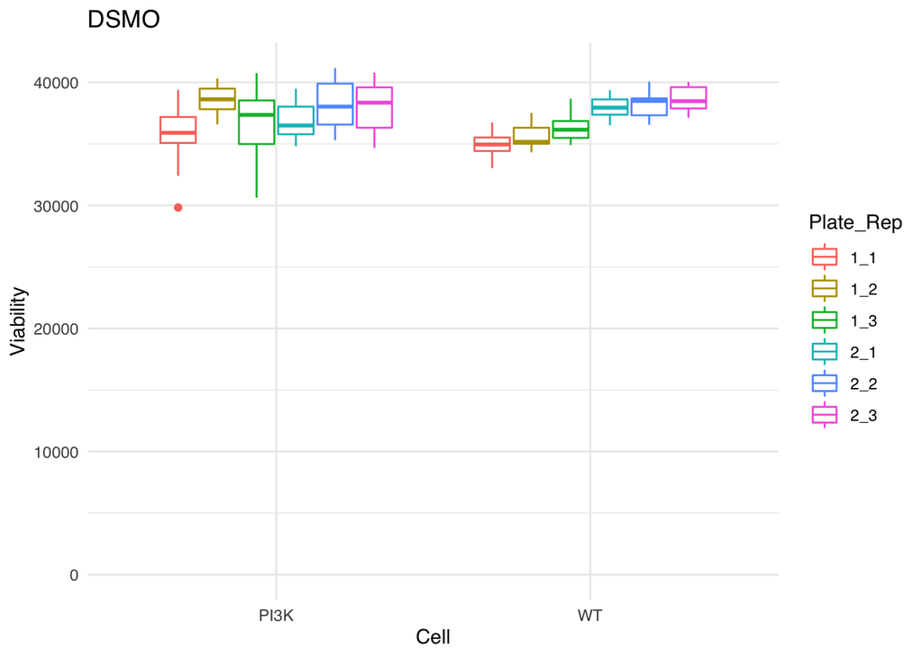

```r
df <- bind_rows(list("WT" = wt, "PI3K" = pi3k), .id = "Cell") %>%
  filter(Drug == "DSMO") %>%
  unite(Plate_Rep, Plate, Rep) %>%
  ungroup()

ggplot(df, aes(x = Cell, y = Viability)) +
  geom_boxplot(aes(color = Plate_Rep)) +
  expand_limits(y = 0) +
  ggtitle("DSMO") +
  theme_minimal(base_family = "Helvetica")
```

There is no clear differences in viability between the WT and PI3K mutant cells. However, the viability does differ somewhat between plates.

Next, we combine the technical replicates and Normalize the data. Normalize by first subtracting the PAO (= positive control) from the viability measurement and than dividing by (DSMO -PAO) (= negative control).

TODO: Normalize the viability per plate.

```r
normalize_viability <- function(df){
  pao_mean <- mean(dplyr::pull(dplyr::filter(df, Drug == "PAO")))
  dsmo_mean <- mean(dplyr::pull(dplyr::filter(df, Drug == "DSMO")))
  df %>% mutate(
    NormalizedViability = (Viability - pao_mean)/(dsmo_mean - pao_mean)
    )
}

wt <- wt %>%
  summarise(Viability = mean(Viability)) %>%
  normalize_viability()
pi3k <- pi3k %>%
  summarise(Viability = mean(Viability)) %>%
  normalize_viability()

viabilities <- bind_rows(list("WT" = wt, "PI3K" = pi3k), .id = "Cell") %>%
  filter(!(Drug %in% c("DSMO", "PAO"))) %>%
  # Remove HERi, ALKi and FGFRi as these are not used in perturbation experiments
  filter(!(Drug %in% c("HER2i (Lapatinib)", "ALKi (Crizotinib)", "FGFRi (AZD4547)"))) %>%
  mutate(Cell = factor(Cell, levels = c("WT", "PI3K")))
```

# Plot drug-response curves

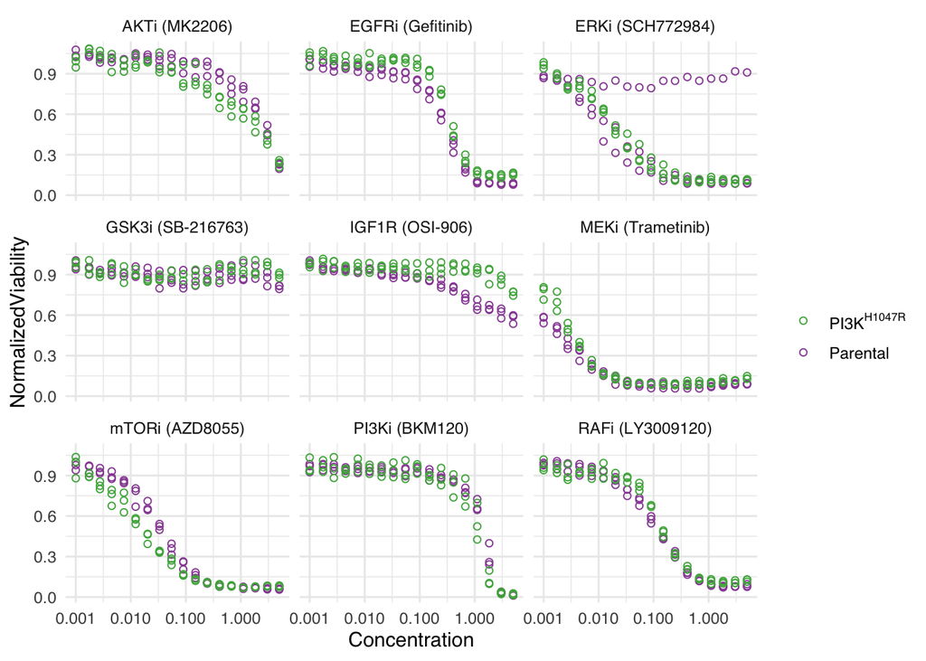

```r
ggplot(viabilities, aes(x = Concentration, y = NormalizedViability, color = Cell)) +
  geom_point(shape = 1) +
  scale_x_log10() +
  theme_minimal(base_family = "Helvetica") +
  scale_color_manual(name = "", values = color_lst, labels = label_lst) +
  facet_wrap(~Drug)
```

One replicate of WT ERKi and HER2i appears to not have been disposed. Let’s find and remove it from the date frame.

```r
filter(viabilities, Drug %in% c("ERKi (SCH772984)", "HER2i (Lapatinib)"),
       Concentration == 5, NormalizedViability > 0.5)
```

| Cell | Plate | Rep | Drug | Concentration | Viability | NormalizedViability |
| --- | --- | --- | --- | --- | --- | --- |
| WT | 1 | 1 | ERKi (SCH772984) | 5 | 33813 | 0.9092938 |

```r
annot %>%
  filter(Drug %in% c("ERKi (SCH772984)", "HER2i (Lapatinib)")) %>%
  mutate(Row = str_sub(Well, 0, 1)) %>%
  select(Drug, Row) %>%
  distinct()
```

| Drug | Row |
| --- | --- |
| ERKi (SCH772984) | I |
| ERKi (SCH772984) | J |
| HER2i (Lapatinib) | K |
| HER2i (Lapatinib) | L |

These drugs are located next to each other on the plate, so a printing mistake is the likely cause. We remove these from the data.

```r
viabilities_filtered <- filter(
  viabilities,
  !(Drug %in% c("ERKi (SCH772984)", "HER2i (Lapatinib)") & Rep == 1)
)
write_tsv(viabilities_filtered, here("results", "pilot", "viabilities-pilot.tsv"))
```

# Fit IC50s and AUC

We fit IC50 to these curves using Daniel Vis mixed IC50 package.

```r
x_mapping <- tibble(
  Concentration = rev(unique(viabilities_filtered$Concentration)),
  x = getXfromConcSeries(rev(unique(viabilities_filtered$Concentration))/5)
  )

gDat <- viabilities_filtered %>%
  ungroup() %>%
  left_join(x_mapping) %>%
  mutate(y = 1 - if_else(NormalizedViability > 1, 1, NormalizedViability),
         maxc = 5) %>%
  rename(CL = Cell, drug = Drug) %>%
  select(x, y, CL, drug, maxc)

fit <- fitModel(gDat, bLargeScale = FALSE)
outStats <- gatherModelStats(gDat, fit)
```

```r
dat_ic50 <- outStats$IC50 %>%
  rownames_to_column("Cell") %>%
  gather(Drug, Log_IC50, -Cell) %>%
  mutate(Drug = str_replace(Drug, "DrugID", ""), IC50 = exp(Log_IC50))

dat_auc <- outStats$AUC %>%
  rownames_to_column("Cell") %>%
  gather(Drug, AUC, -Cell) %>%
  mutate(Drug = str_replace(Drug, "DrugID", ""))

dat_auctrap <- outStats$AUCtrap %>%
  rownames_to_column("Cell") %>%
  gather(Drug, AUCtrap, -Cell) %>%
  mutate(Drug = str_replace(Drug, "DrugID", ""))

dat_ic10 <- outStats$mcv %>%
  mutate(IC10 = getConcentrationFromFold(xmid - scal*log(1/0.1 - 1), fHighConc = 5)) %>%
  rename(Cell = CL, Drug = drug) %>%
  select(Cell, Drug, IC10)

dat_ic90 <- outStats$mcv %>%
  mutate(IC90 = getConcentrationFromFold(xmid - scal*log(1/0.9 - 1), fHighConc = 5)) %>%
  rename(Cell = CL, Drug = drug) %>%
  select(Cell, Drug, IC90)

df_sensitivities <- dat_ic50 %>%
  left_join(dat_ic10) %>%
  left_join(dat_ic90) %>%
  left_join(dat_auc) %>%
  left_join(dat_auctrap)

write_tsv(df_sensitivities, here("results/pilot/drug-sensitivities-pilot.tsv"))

df_sensitivities
```

| Cell | Drug | Log_IC50 | IC50 | IC10 | IC90 | AUC | AUCtrap |
| --- | --- | --- | --- | --- | --- | --- | --- |
| WT | AKTi (MK2206) | 0.98878444 | 2.687965095 | 0.3074677141 | 23.49891068 | 0.8776603 | 0.43362542 |
| PI3K | AKTi (MK2206) | 0.42215651 | 1.525247224 | 0.1744681428 | 13.33411966 | 0.8302530 | 0.20713881 |
| WT | EGFRi (Gefitinib) | -1.26245387 | 0.282958829 | 0.0323667538 | 2.47370186 | 0.6570482 | -0.14519413 |
| PI3K | EGFRi (Gefitinib) | -0.74479196 | 0.474833072 | 0.0543146336 | 4.15111786 | 0.7136168 | 0.01890842 |
| WT | ERKi (SCH772984) | -4.28522916 | 0.013770466 | 0.0015751594 | 0.12038510 | 0.3154660 | -0.78400598 |
| PI3K | ERKi (SCH772984) | -3.77775292 | 0.022874033 | 0.0026164874 | 0.19997093 | 0.3717581 | -0.72979810 |
| WT | GSK3i (SB-216763) | 2.78602089 | 16.216364597 | 1.8549379840 | 141.76780195 | 0.9692974 | -0.09860563 |
| PI3K | GSK3i (SB-216763) | 3.53245793 | 34.207945157 | 3.9129372391 | 299.05501682 | 0.9845740 | -0.14076444 |
| WT | IGF1R (OSI-906) | 1.24111020 | 3.459452008 | 0.3957156300 | 30.24345587 | 0.8960953 | -0.04595542 |
| PI3K | IGF1R (OSI-906) | 2.73976021 | 15.483271911 | 1.7710818631 | 135.35890918 | 0.9680101 | 0.08681136 |

[output cut: 8 more lines]

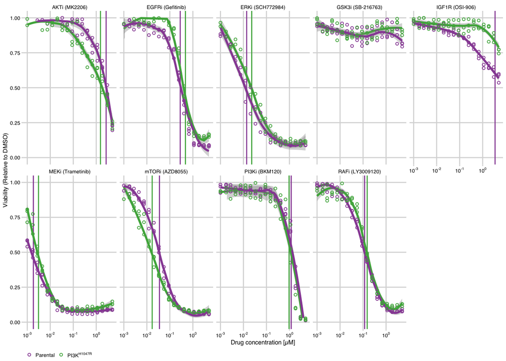

```r
ggplot(
  mutate(viabilities_filtered, Cell = fct_relevel(Cell, "PI3K")) %>%
    filter(!(Drug %in% c("HER2i (Lapatinib)", "ALKi (Crizotinib)", "FGFRi (AZD4547)"))),
  aes(
    x = Concentration,
    y = NormalizedViability,
    color = Cell,
    group = Cell
  )) +
  geom_vline(aes(xintercept = IC50, color = Cell),
             data = dat_ic50,
             show.legend = FALSE) +
  geom_smooth(show.legend = FALSE) +
  geom_point(shape = 1, size=1) +
  scale_x_log10(
    limits = c(
      min(viabilities_filtered$Concentration),
      max(viabilities_filtered$Concentration)
    ),
    breaks =  scales::trans_breaks("log10", function(x)
      10 ^ x),
    labels = scales::trans_format("log10", scales::math_format(10 ^.x))
  ) +
  scale_y_continuous(limits = c(0, 1)) +
  facet_wrap( ~ Drug, nrow=2) +
  # No gray background in legend
  # guides(color = guide_legend(override.aes = list(fill = NA))) +
  cowplot::theme_minimal_grid(font_family = "Helvetica", font_size = 6) +
  # theme_minimal() +
  # theme(strip.text = element_text(hjust = 0), text=element_text(size=6, family = "Helvetica")) +
  labs(x = "Drug concentration [µM]", y = "Viability (Relative to DMSO)") +
  scale_color_manual(name = "",
                     breaks = c("WT", "PI3K"),
                     values = color_lst,
                     labels = label_lst) +
  theme(legend.position = "bottom")
```

```r
ggsave(here("figures", "EnVision", "dose-response-pilot-all.pdf"), width = 6, height = 2.5)
```

# Conclusion

- WT is more sensitive to MAPK targeting drugs.
  - EGFRi and HER2i
  - ERKi
  - MEKi
- PI3K mutant is more sensitive to AKT-pathway targeting drugs
  - AKTi
  - mTORi
- Not difference in sensitivity to PI3Ki (slightly unexpected).

But all effects are really subtle.